# Data Project - Stock Exchange Data

Samuel Kihuguru

12/10/2021

```r
library(tidyverse)
library(lubridate)
```

============================================

## Stock Index Project

```r
indexD <- read_csv("indexData.csv")
indexI <- read_csv("indexInfo.csv")
indexP <- read_csv("indexProcessed.csv")
```

Before undertaking the data analysis process, the datasets of interest must be cleaned and made consistent. There are three datasets we are working on: indexD, indexI, and indexP. Each of these tables has variables that require changes to their data type. For example, the Index column in indexD which shows the ticker symbols for each of the exchanges would need to move from a character(“chr”) variable to a factor variable.

```r
# Index in indexD needs to be a Factor
indexD$Index <- factor(indexD$Index)

# Open, High, Low, Close, Adj Close, Volume need to be numeric
indexD$Open <- as.numeric(indexD$Open)
indexD$High <- as.numeric(indexD$High)
indexD$Low <- as.numeric(indexD$Low)
indexD$Close <- as.numeric(indexD$Close)
indexD$`Adj Close` <- as.numeric(indexD$`Adj Close`)
indexD$Volume <- as.numeric(indexD$Volume)

# Data cleaning for indexInfo
indexI$Region <- factor(indexI$Region)
indexI$Exchange <- factor(indexI$Exchange)
indexI$Index <- factor(indexI$Index)
indexI$Currency <- factor(indexI$Currency)

# Data cleaning for indexProcessed
indexP$Index <- factor(indexP$Index)
```

Throughout the report, you will encounter Index symbols associated with the Exchanges. The following are the ticker symbols with their exchange name:

- NYA — New York Stock Exchange
- IXIC — NASDAQ
- HSI — Hong Kong Stock Exchange
- 000001.SS — Shanghai Stock Exchange
- N225 — Tokyo Stock Exchange
- N100 — Euronext
- 399001.SZ — Shenzhen Stock Exchange
- GSPSTE — Toronto Stock Exchange
- NSEI — National Stock Exchange of India
- GDAX1 — Frankfurt Stock Exchange
- KS11 — Korea Exchange
- SSMI — SIX Swiss Exchange
- TWII — Taiwan Stock Exchange
- J203.JO — Johannesburg Stock Exchange

```r
indexI %>%
  select(Index,Exchange,Region)
```

```
## # A tibble: 14 x 3
##    Index     Exchange                         Region
##    <fct>     <fct>                            <fct>
##  1 NYA       New York Stock Exchange          United States
##  2 IXIC      NASDAQ                           United States
##  3 HSI       Hong Kong Stock Exchange         Hong Kong
##  4 000001.SS Shanghai Stock Exchange          China
##  5 N225      Tokyo Stock Exchange             Japan
##  6 N100      Euronext                         Europe
##  7 399001.SZ Shenzhen Stock Exchange          China
##  8 GSPTSE    Toronto Stock Exchange           Canada
##  9 NSEI      National Stock Exchange of India India
## 10 GDAXI     Frankfurt Stock Exchange         Germany
## 11 KS11      Korea Exchange                   Korea
## 12 SSMI      SIX Swiss Exchange               Switzerland
## 13 TWII      Taiwan Stock Exchange            Taiwan
## 14 J203.JO   Johannesburg Stock Exchange      South Africa
```

## Including Plots

*Q1*

What is the average price return by Index? What is the Daily Return and Daily Return (%) for each index price?

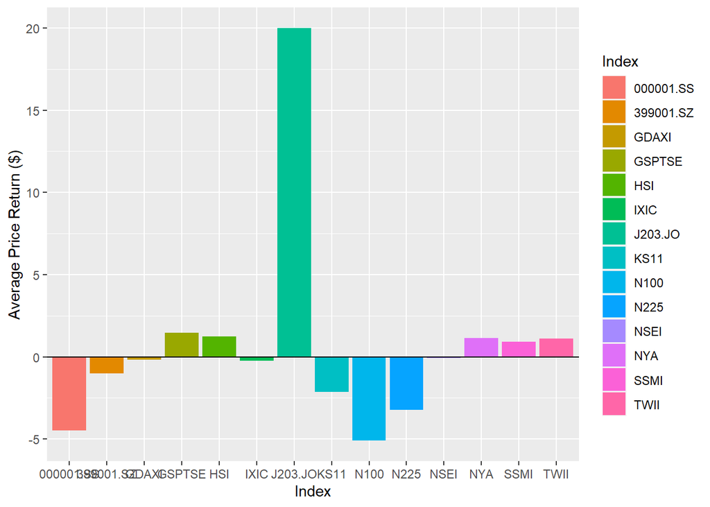

```r
indexD %>%
  mutate(Daily_Return = `Adj Close`-lag(`Adj Close`)) %>%
  mutate(Daily_Return_Perc. = (`Adj Close`-lag(`Adj Close`))*100/lag(`Adj Close`)) %>%
  select(Index, Date, Open, High, Low, Close, Daily_Return,Daily_Return_Perc.) %>%
  group_by(Index) %>%
  summarize(Avg_Return = mean(Daily_Return, na.rm = TRUE), Avg_Return_Perc. =   mean(Daily_Return_Perc., na.rm = TRUE)) %>%
  ggplot(aes(Index, Avg_Return, fill = Index))+
  geom_bar(stat = "identity")+
  geom_hline(yintercept = 0)+
  ylab("Average Price Return ($)")
```

*Q2*

Let’s take a look at the exchange returns across time. What is the Daily Return(%) over time by Index? Are there noticeable anomalies?

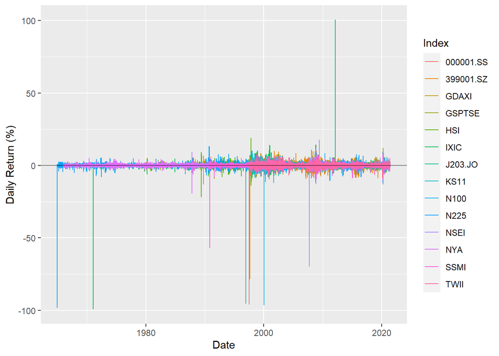

```r
# Daily Return(%) against time (color by index)
indexD %>%
  mutate(Daily_Return = `Adj Close`-lag(`Adj Close`)) %>%
  mutate(Daily_Return_Perc. = ((`Adj Close`-lag(`Adj Close`))*100)/lag(`Adj Close`)) %>%
  ggplot(aes(Date, Daily_Return_Perc.)) +
  geom_line(aes(color = Index))+
  geom_hline(aes(yintercept = 0), color = "black", alpha = 0.5)+
  ylab("Daily Return (%)")
```

Using Daily Return and Daily Return Percentage is very useful in standardizing the data and allow us to work with mean and standard deviation data in later plots.

```r
# Incorporating Daily_Return and Daily_Return_Perc. into dataset
indexD$Daily_Return <- indexD$`Adj Close`-lag(indexD$`Adj Close`)
indexD$Daily_Return_Perc. <- (indexD$`Adj Close`-lag(indexD$`Adj Close`))*100/lag(indexD$`Adj Close`)
```

Left joining indexD data with indexI that contains the Exchange name and countries associated with each Index. New index would be called “fullindex” and extracts “Year” from the Date column.

```r
# Left join indexI for countries by Index
fullindex <- indexI %>%
  left_join(indexD)
fullindex$Year <- as.POSIXlt(fullindex$Date)$year + 1900
```

*Q3*

Stock exchanges play into the risk-reward relationship. Ideally, the more risk you take on, the higher the reward to compensate for higher risk. Is there a correlation in the data between average return and volatility (standard deviation)? Do some indexes experience higher reward for lower risk?

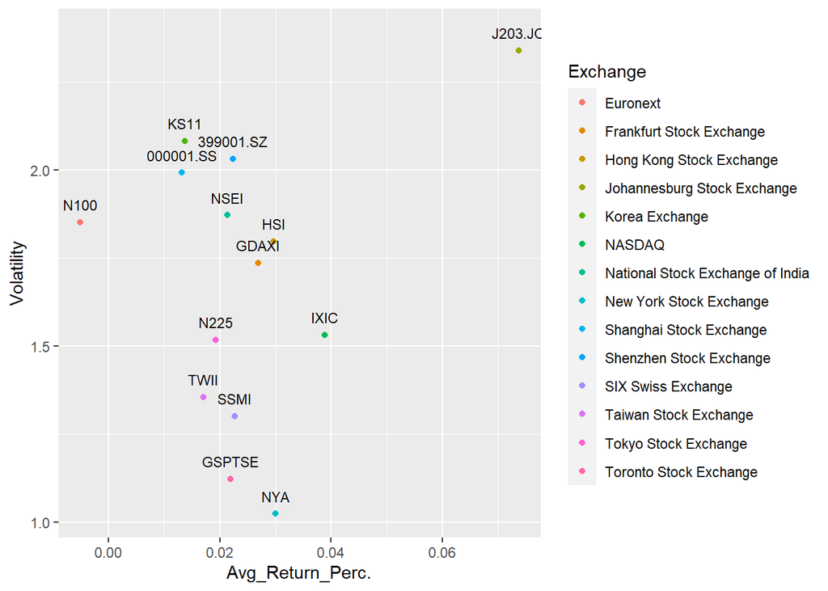

```r
fullindex%>%
  group_by(Region,Index,Exchange) %>%
  summarize(Count = n(), Avg_Return = mean(Daily_Return, na.rm = TRUE),
            Avg_Return_Perc. = mean(Daily_Return_Perc., na.rm = TRUE),
            Volatility = sd(Daily_Return_Perc., na.rm = TRUE),  #,
            Duration = year(today()) - min(as.POSIXlt(Date)$year + 1900))%>%
  arrange(desc(Avg_Return_Perc.)) %>%
  ggplot(aes(Avg_Return_Perc., Volatility))+
  geom_point(aes(color = Exchange))+
  geom_text(aes(label = paste0(Index)), nudge_y = 0.05, size=3)
```

It appears that there is no clear direct correlation with the exchange data provided between average return percentage and standard deviation. As a result, you have indexes like the NYA (New York Stock Exchange) that generates the same mean price return for lower volatility than GSPTSE, SSMI, TWII, etc.

*Q4*

It is noticeable that some exchanges have been in place longer than others, and this seems to affect the return results. The Johannesburg Stock Exchange, for example, tends to show strong volatility and average return compared to large long-running exchanges. Is there an inverse relationship between index duration and avg_return_perc.?

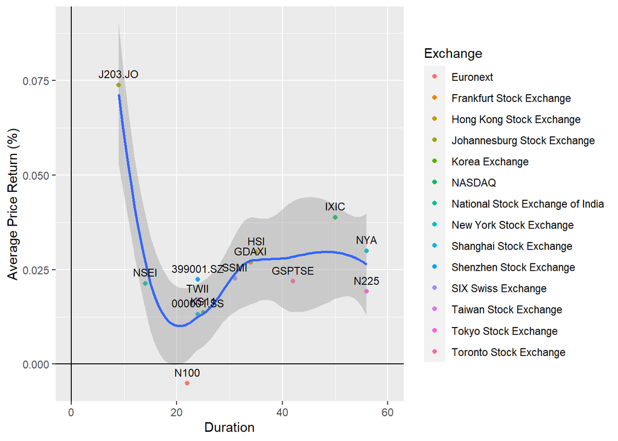

```r
fullindex %>%
  group_by(Region,Exchange,Index) %>%
  summarize(Count = n(), Avg_Return = mean(Daily_Return, na.rm = TRUE),
            Avg_Return_Perc. = mean(Daily_Return_Perc., na.rm = TRUE), #,
            Duration = year(today()) - min(as.POSIXlt(Date)$year + 1900)) %>%
  ggplot(aes(Duration,Avg_Return_Perc.))+
  geom_point(aes(color = Exchange))+
  geom_smooth()+
  geom_text(aes(label = paste0(Index)),nudge_y=0.003, size=3)+
  geom_hline(yintercept=0)+
  geom_vline(xintercept=0)+
  coord_cartesian(xlim=c(0,60))+
  ylab("Average Price Return (%)")
```

*Q5*

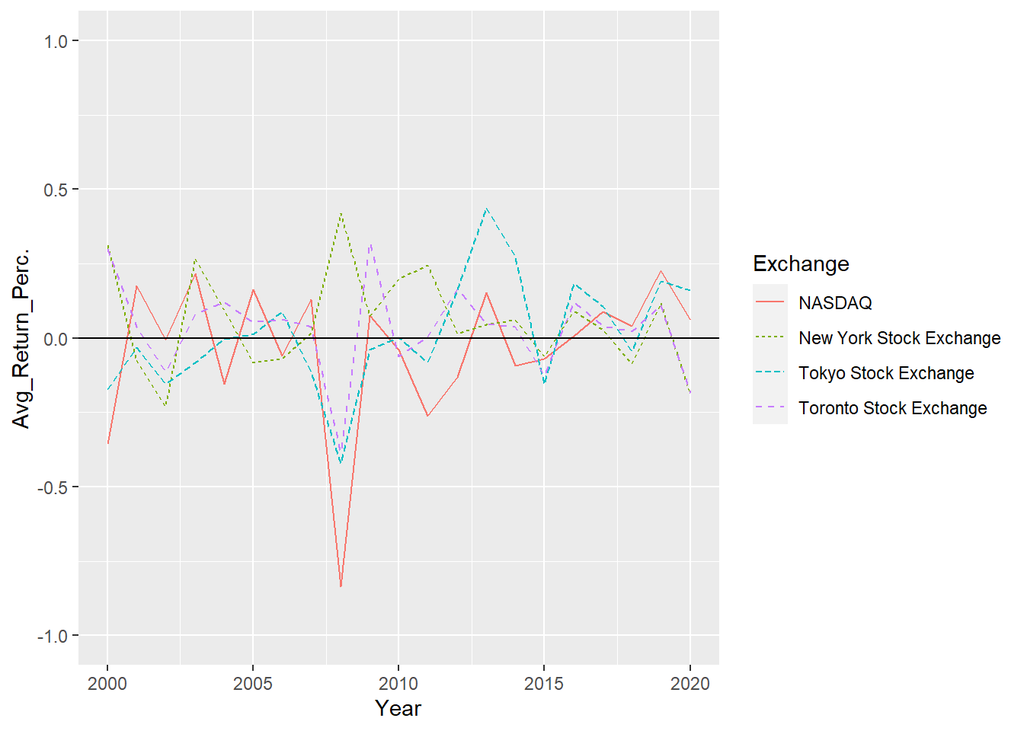

```r
fullindex %>%
  filter(Index == c("NYA","IXIC","GSPTSE","N225")) %>%
  group_by(Index, Exchange, Year) %>%
  summarize(Avg_Return_Perc. = mean(Daily_Return_Perc., na.rm = TRUE)) %>%
  ggplot(aes(Year, Avg_Return_Perc.))+
  geom_line(aes(color = Exchange, linetype = Exchange))+
  geom_hline(yintercept=0)+
  xlim(2000,2020)+
  ylim(-1,1)
```

*Q6*

Create a new index composed of the four chosen indices and track its projection over time.

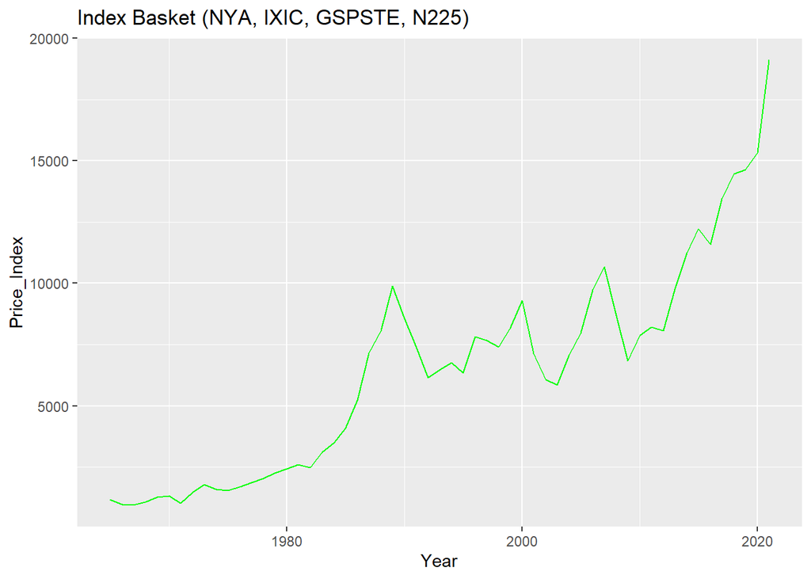

```r
new_index_large <- fullindex %>%
  filter(Index == c("NYA","IXIC","GSPTSE","N225")) %>%
  group_by(Year) %>%
  summarize(Price_Index = mean(`Adj Close`, na.rm = TRUE)) %>%
  ggplot()+
  geom_line(aes(Year, Price_Index), color="green")+
  labs(title = "Index Basket (NYA, IXIC, GSPSTE, N225)")
new_index_large
```

*Q7*